# Biostat 200C Homework 1

Due Apr 17 @ 11:59PM

To sumbit homework, please email Rmd and html files to TA Shanpeng Li by the deadline.

## Q1. Concavity of logistic regression log-likelihood

### Q1.1

Write down the log-likelihood function of logistic regresion for binomial responses.

### Q1.2

Derive the gradient vector and Hessian matrix of the log-likelhood function with respect to the regression coefficients $\boldsymbol{\beta}$.

### Q1.3

Show that the log-likelihood function of logistic regression is a concave function in regression coefficients $\boldsymbol{\beta}$. (Hint: show that the negative Hessian is a positive semidefinite matrix.)

## Q2. CFR of COVID-19

Of primary interest to public is the risk of dying from COVID-19. A commonly used measure is case fatality rate/ratio/risk (CFR), which is defined as
$$\frac{\text{number of deaths from disease}}{\text{number of diagnosed cases of disease}}.$$
Apparently CFR is not a fixed constant; it changes with time, location, and other factors. Also CFR is different from the infection fatality rate (IFR), the probability that someone infected with COVID-19 dies from it.

In this exercise, we use logistic regression to study how US county-level CFR changes according to demographic information and some health-, education-, and economy-indicators.

### Data sources

- `04-04-2020.csv.gz`: The data on COVID-19 confirmed cases and deaths on 2020-04-04 is retrieved from the [Johns Hopkins COVID-19 data repository](https://github.com/CSSEGISandData/COVID-19). It was downloaded from this [link](https://github.com/CSSEGISandData/COVID-19) (commit 0174f38).
- `us-county-health-rankings-2020.csv.gz`: The 2020 County Health Ranking Data was released by [County Health Rankings](https://www.countyhealthrankings.org). The data was downloaded from the [Kaggle Uncover COVID-19 Challenge](https://www.kaggle.com/roche-data-science-coalition/uncover) (version 1).

### Sample code for data preparation

Load the `tidyverse` package for data manipulation and visualization.

```r
# tidyverse of data manipulation and visualization
library(tidyverse)
```

Read in the data of COVID-19 cases reported on 2020-04-04.

```r
county_count <- read_csv("./04-04-2020.csv.gz") %>%
  # cast fips into dbl for use as a key for joining tables
  mutate(FIPS = as.numeric(FIPS)) %>%
  filter(Country_Region == "US") %>%
  print(width = Inf)
```

```
## # A tibble: 2,421 x 12
##     FIPS Admin2    Province_State Country_Region Last_Update           Lat
##    <dbl> <chr>     <chr>          <chr>          <dttm>              <dbl>
##  1 45001 Abbeville South Carolina US             2020-04-04 23:34:21  34.2
##  2 22001 Acadia    Louisiana      US             2020-04-04 23:34:21  30.3
##  3 51001 Accomack  Virginia       US             2020-04-04 23:34:21  37.8
##  4 16001 Ada       Idaho          US             2020-04-04 23:34:21  43.5
##  5 19001 Adair     Iowa           US             2020-04-04 23:34:21  41.3
##  6 21001 Adair     Kentucky       US             2020-04-04 23:34:21  37.1
##  7 29001 Adair     Missouri       US             2020-04-04 23:34:21  40.2
##  8 40001 Adair     Oklahoma       US             2020-04-04 23:34:21  35.9
##  9  8001 Adams     Colorado       US             2020-04-04 23:34:21  39.9
## 10 16003 Adams     Idaho          US             2020-04-04 23:34:21  44.9
##     Long_ Confirmed Deaths Recovered Active Combined_Key
##     <dbl>     <dbl>  <dbl>     <dbl>  <dbl> <chr>
##  1  -82.5         6      0         0      0 Abbeville, South Carolina, US
##  2  -92.4        65      2         0      0 Acadia, Louisiana, US
##  3  -75.6         8      0         0      0 Accomack, Virginia, US
##  4 -116.        360      3         0      0 Ada, Idaho, US
##  5  -94.5         1      0         0      0 Adair, Iowa, US
##  6  -85.3         3      0         0      0 Adair, Kentucky, US
##  7  -92.6        10      0         0      0 Adair, Missouri, US
##  8  -94.7        14      0         0      0 Adair, Oklahoma, US
##  9 -104.        294      9         0      0 Adams, Colorado, US
## 10 -116.          1      0         0      0 Adams, Idaho, US
## # … with 2,411 more rows
```

Standardize the variable names by changing them to lower case.

```r
names(county_count) <- str_to_lower(names(county_count))
```

Sanity check by displaying the unique US states and territories:

```r
county_count %>%
  select(province_state) %>%
  distinct() %>%
  arrange(province_state) %>%
  print(n = Inf)
```

```
## # A tibble: 58 x 1
##    province_state
##    <chr>
##  1 Alabama
##  2 Alaska
##  3 Arizona
##  4 Arkansas
##  5 California
##  6 Colorado
##  7 Connecticut
##  8 Delaware
##  9 Diamond Princess
## 10 District of Columbia
## 11 Florida
## 12 Georgia
```

[output cut: 46 more lines]

We want to exclude entries from `Diamond Princess`, `Grand Princess`, `Guam`, `Northern Mariana Islands`, `Puerto Rico`, `Recovered`, and `Virgin Islands`, and only consider counties from 50 states and DC.

```r
county_count <- county_count %>%
  filter(!(province_state %in% c("Diamond Princess", "Grand Princess",
                                 "Recovered", "Guam", "Northern Mariana Islands",
                                 "Puerto Rico", "Virgin Islands"))) %>%
  print(width = Inf)
```

```
## # A tibble: 2,413 x 12
##     fips admin2    province_state country_region last_update           lat
##    <dbl> <chr>     <chr>          <chr>          <dttm>              <dbl>
##  1 45001 Abbeville South Carolina US             2020-04-04 23:34:21  34.2
##  2 22001 Acadia    Louisiana      US             2020-04-04 23:34:21  30.3
##  3 51001 Accomack  Virginia       US             2020-04-04 23:34:21  37.8
##  4 16001 Ada       Idaho          US             2020-04-04 23:34:21  43.5
##  5 19001 Adair     Iowa           US             2020-04-04 23:34:21  41.3
##  6 21001 Adair     Kentucky       US             2020-04-04 23:34:21  37.1
##  7 29001 Adair     Missouri       US             2020-04-04 23:34:21  40.2
##  8 40001 Adair     Oklahoma       US             2020-04-04 23:34:21  35.9
##  9  8001 Adams     Colorado       US             2020-04-04 23:34:21  39.9
## 10 16003 Adams     Idaho          US             2020-04-04 23:34:21  44.9
##     long_ confirmed deaths recovered active combined_key
##     <dbl>     <dbl>  <dbl>     <dbl>  <dbl> <chr>
##  1  -82.5         6      0         0      0 Abbeville, South Carolina, US
##  2  -92.4        65      2         0      0 Acadia, Louisiana, US
##  3  -75.6         8      0         0      0 Accomack, Virginia, US
##  4 -116.        360      3         0      0 Ada, Idaho, US
##  5  -94.5         1      0         0      0 Adair, Iowa, US
##  6  -85.3         3      0         0      0 Adair, Kentucky, US
##  7  -92.6        10      0         0      0 Adair, Missouri, US
##  8  -94.7        14      0         0      0 Adair, Oklahoma, US
##  9 -104.        294      9         0      0 Adams, Colorado, US
## 10 -116.          1      0         0      0 Adams, Idaho, US
## # … with 2,403 more rows
```

Graphical summarize the COVID-19 confirmed cases and deaths on 2020-04-04 by state.

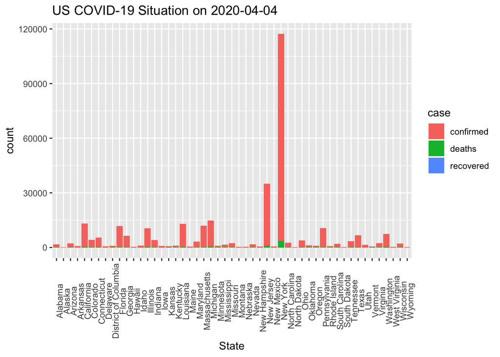

```r
county_count %>%
  # turn into long format for easy plotting
  pivot_longer(confirmed:recovered,
               names_to = "case",
               values_to = "count") %>%
  group_by(province_state) %>%
  ggplot() +
  geom_col(mapping = aes(x = province_state, y = `count`, fill = `case`)) +
  # scale_y_log10() +
  labs(title = "US COVID-19 Situation on 2020-04-04", x = "State") +
  theme(axis.text.x = element_text(angle = 90))
```

Read in the 2020 county-level health ranking data.

```r
county_info <- read_csv("./us-county-health-rankings-2020.csv.gz") %>%
  filter(!is.na(county)) %>%
  # cast fips into dbl for use as a key for joining tables
  mutate(fips = as.numeric(fips)) %>%
  select(fips,
         state,
         county,
         percent_fair_or_poor_health,
         percent_smokers,
         percent_adults_with_obesity,
         # food_environment_index,
         percent_with_access_to_exercise_opportunities,
         percent_excessive_drinking,
         # teen_birth_rate,
         percent_uninsured,
         # primary_care_physicians_rate,
         # preventable_hospitalization_rate,
         # high_school_graduation_rate,
         percent_some_college,
         percent_unemployed,
         percent_children_in_poverty,
         # `80th_percentile_income`,
         # `20th_percentile_income`,
         percent_single_parent_households,
         # violent_crime_rate,
         percent_severe_housing_problems,
         overcrowding,
         # life_expectancy,
         # age_adjusted_death_rate,
         percent_adults_with_diabetes,
         # hiv_prevalence_rate,
         percent_food_insecure,
         # percent_limited_access_to_healthy_foods,
         percent_insufficient_sleep,
         percent_uninsured_2,
         median_household_income,
         average_traffic_volume_per_meter_of_major_roadways,
         percent_homeowners,
         # percent_severe_housing_cost_burden,
         population_2,
         percent_less_than_18_years_of_age,
         percent_65_and_over,
         percent_black,
         percent_asian,
         percent_hispanic,
         percent_female,
         percent_rural) %>%
  print(width = Inf)
```

```
## # A tibble: 3,142 x 30
##     fips state   county   percent_fair_or_poor_health percent_smokers
##    <dbl> <chr>   <chr>                          <dbl>           <dbl>
##  1  1001 Alabama Autauga                         20.9            18.1
##  2  1003 Alabama Baldwin                         17.5            17.5
##  3  1005 Alabama Barbour                         29.6            22.0
##  4  1007 Alabama Bibb                            19.4            19.1
##  5  1009 Alabama Blount                          21.7            19.2
##  6  1011 Alabama Bullock                         31.0            22.9
##  7  1013 Alabama Butler                          27.9            21.8
##  8  1015 Alabama Calhoun                         23.1            20.6
##  9  1017 Alabama Chambers                        24.0            19.4
## 10  1019 Alabama Cherokee                        20.7            17.5
##    percent_adults_with_obesity percent_with_access_to_exercise_opportunities
##                          <dbl>                                         <dbl>
```

[output cut: 107 more lines]

For stability in estimating CFR, we restrict to counties with $\ge 5$ confirmed cases.

```r
county_count <- county_count %>%
  filter(confirmed >= 5)
```

We join the COVID-19 count data and county-level information using FIPS (Federal Information Processing System) as key.

```r
county_data <- county_count %>%
  left_join(county_info, by = "fips") %>%
  print(width = Inf)
```

```
## # A tibble: 1,466 x 41
##     fips admin2    province_state country_region last_update           lat
##    <dbl> <chr>     <chr>          <chr>          <dttm>              <dbl>
##  1 45001 Abbeville South Carolina US             2020-04-04 23:34:21  34.2
##  2 22001 Acadia    Louisiana      US             2020-04-04 23:34:21  30.3
##  3 51001 Accomack  Virginia       US             2020-04-04 23:34:21  37.8
##  4 16001 Ada       Idaho          US             2020-04-04 23:34:21  43.5
##  5 29001 Adair     Missouri       US             2020-04-04 23:34:21  40.2
##  6 40001 Adair     Oklahoma       US             2020-04-04 23:34:21  35.9
##  7  8001 Adams     Colorado       US             2020-04-04 23:34:21  39.9
##  8 28001 Adams     Mississippi    US             2020-04-04 23:34:21  31.5
##  9 31001 Adams     Nebraska       US             2020-04-04 23:34:21  40.5
## 10 42001 Adams     Pennsylvania   US             2020-04-04 23:34:21  39.9
##     long_ confirmed deaths recovered active combined_key
##     <dbl>     <dbl>  <dbl>     <dbl>  <dbl> <chr>
```

[output cut: 131 more lines]

Numerical summaries of each variable:

```r
summary(county_data)
```

```
##       fips          admin2          province_state     country_region
##  Min.   : 1001   Length:1466        Length:1466        Length:1466
##  1st Qu.:18003   Class :character   Class :character   Class :character
##  Median :29029   Mode  :character   Mode  :character   Mode  :character
##  Mean   :30076
##  3rd Qu.:42077
##  Max.   :90053
##  NA's   :13
##   last_update                       lat            long_
##  Min.   :2020-04-04 23:34:21   Min.   :19.60   Min.   :-159.60
##  1st Qu.:2020-04-04 23:34:21   1st Qu.:33.96   1st Qu.: -94.56
##  Median :2020-04-04 23:34:21   Median :38.02   Median : -86.48
##  Mean   :2020-04-04 23:34:21   Mean   :37.71   Mean   : -89.73
##  3rd Qu.:2020-04-04 23:34:21   3rd Qu.:41.38   3rd Qu.: -81.22
##  Max.   :2020-04-04 23:34:21   Max.   :64.81   Max.   : -68.65
##                                NA's   :19      NA's   :19
##    confirmed           deaths           recovered     active
##  Min.   :    5.0   Min.   :   0.000   Min.   :0   Min.   :0
##  1st Qu.:    9.0   1st Qu.:   0.000   1st Qu.:0   1st Qu.:0
##  Median :   20.0   Median :   0.000   Median :0   Median :0
##  Mean   :  208.8   Mean   :   4.842   Mean   :0   Mean   :0
##  3rd Qu.:   68.0   3rd Qu.:   2.000   3rd Qu.:0   3rd Qu.:0
##  Max.   :63306.0   Max.   :1905.000   Max.   :0   Max.   :0
##
##  combined_key          state              county
##  Length:1466        Length:1466        Length:1466
##  Class :character   Class :character   Class :character
##  Mode  :character   Mode  :character   Mode  :character
##
##
##
##
##  percent_fair_or_poor_health percent_smokers  percent_adults_with_obesity
##  Min.   : 8.121              Min.   : 5.909   Min.   :12.40
##  1st Qu.:14.390              1st Qu.:14.899   1st Qu.:29.10
##  Median :17.010              Median :17.147   Median :32.95
##  Mean   :17.594              Mean   :17.153   Mean   :32.41
##  3rd Qu.:20.377              3rd Qu.:19.365   3rd Qu.:36.20
##  Max.   :38.887              Max.   :27.775   Max.   :51.00
##  NA's   :28                  NA's   :28       NA's   :28
```

[output cut: 57 more lines]

```
##  Min.   : 7.722      Min.   : 0.1286   Min.   : 0.06245   Min.   : 0.7952
##  1st Qu.:14.927      1st Qu.: 1.6175   1st Qu.: 0.68248   1st Qu.: 2.9419
##  Median :17.222      Median : 5.6397   Median : 1.23421   Median : 5.5939
##  Mean   :17.516      Mean   :12.4178   Mean   : 2.40412   Mean   :10.0010
##  3rd Qu.:19.598      3rd Qu.:17.5931   3rd Qu.: 2.67550   3rd Qu.:11.0564
##  Max.   :57.587      Max.   :81.9544   Max.   :42.95231   Max.   :96.3595
##  NA's   :28          NA's   :28        NA's   :28         NA's   :28
##  percent_female  percent_rural
##  Min.   :34.63   Min.   :  0.00
##  1st Qu.:50.00   1st Qu.: 17.11
##  Median :50.66   Median : 36.97
##  Mean   :50.46   Mean   : 40.11
##  3rd Qu.:51.35   3rd Qu.: 60.00
##  Max.   :56.87   Max.   :100.00
##  NA's   :28      NA's   :28
```

```r
county_data %>%
  filter(is.na(state) & is.na(county)) %>%
  print(n = Inf)
```

```
## # A tibble: 28 x 41
##     fips admin2 province_state country_region last_update           lat  long_
##    <dbl> <chr>  <chr>          <chr>          <dttm>              <dbl>  <dbl>
##  1    NA DeKalb Tennessee      US             2020-04-04 23:34:21  36.0  -85.8
##  2    NA DeSoto Florida        US             2020-04-04 23:34:21  27.2  -81.8
##  3    NA Dukes… Massachusetts  US             2020-04-04 23:34:21  41.4  -70.7
##  4    NA Fillm… Minnesota      US             2020-04-04 23:34:21  43.7  -92.1
##  5    NA Kansa… Missouri       US             2020-04-04 23:34:21  39.1  -94.6
##  6    NA LaSal… Illinois       US             2020-04-04 23:34:21  41.3  -88.9
##  7    NA Manas… Virginia       US             2020-04-04 23:34:21  38.7  -77.5
##  8    NA McDuf… Georgia        US             2020-04-04 23:34:21  33.5  -82.5
##  9    NA Out o… Michigan       US             2020-04-04 23:34:21  NA     NA
## 10    NA Out o… Tennessee      US             2020-04-04 23:34:21  NA     NA
## 11 90005 Unass… Arkansas       US             2020-04-04 23:34:21  NA     NA
## 12 90008 Unass… Colorado       US             2020-04-04 23:34:21  NA     NA
## 13 90009 Unass… Connecticut    US             2020-04-04 23:34:21  NA     NA
## 14 90013 Unass… Georgia        US             2020-04-04 23:34:21  NA     NA
## 15 90015 Unass… Hawaii         US             2020-04-04 23:34:21  NA     NA
## 16 90017 Unass… Illinois       US             2020-04-04 23:34:21  NA     NA
## 17 90021 Unass… Kentucky       US             2020-04-04 23:34:21  NA     NA
## 18    NA Unass… Louisiana      US             2020-04-04 23:34:21  NA     NA
## 19 90023 Unass… Maine          US             2020-04-04 23:34:21  NA     NA
## 20 90025 Unass… Massachusetts  US             2020-04-04 23:34:21  NA     NA
## 21    NA Unass… Michigan       US             2020-04-04 23:34:21  NA     NA
## 22 90032 Unass… Nevada         US             2020-04-04 23:34:21  NA     NA
## 23 90034 Unass… New Jersey     US             2020-04-04 23:34:21  NA     NA
## 24 90044 Unass… Rhode Island   US             2020-04-04 23:34:21  NA     NA
## 25 90047 Unass… Tennessee      US             2020-04-04 23:34:21  NA     NA
## 26 90050 Unass… Vermont        US             2020-04-04 23:34:21  NA     NA
## 27 90053 Unass… Washington     US             2020-04-04 23:34:21  NA     NA
## 28    NA Weber  Utah           US             2020-04-04 23:34:21  41.3 -112.
## # … with 34 more variables: confirmed <dbl>, deaths <dbl>, recovered <dbl>,
## #   active <dbl>, combined_key <chr>, state <chr>, county <chr>,
## #   percent_fair_or_poor_health <dbl>, percent_smokers <dbl>,
## #   percent_adults_with_obesity <dbl>,
## #   percent_with_access_to_exercise_opportunities <dbl>,
## #   percent_excessive_drinking <dbl>, percent_uninsured <dbl>,
## #   percent_some_college <dbl>, percent_unemployed <dbl>,
## #   percent_children_in_poverty <dbl>, percent_single_parent_households <dbl>,
## #   percent_severe_housing_problems <dbl>, overcrowding <dbl>,
## #   percent_adults_with_diabetes <dbl>, percent_food_insecure <dbl>,
## #   percent_insufficient_sleep <dbl>, percent_uninsured_2 <dbl>,
## #   median_household_income <dbl>,
## #   average_traffic_volume_per_meter_of_major_roadways <dbl>,
## #   percent_homeowners <dbl>, population_2 <dbl>,
## #   percent_less_than_18_years_of_age <dbl>, percent_65_and_over <dbl>,
## #   percent_black <dbl>, percent_asian <dbl>, percent_hispanic <dbl>,
## #   percent_female <dbl>, percent_rural <dbl>
```

We found there are some rows that miss `fips`.

```r
county_count %>%
  filter(is.na(fips)) %>%
  select(fips, admin2, province_state) %>%
  print(n = Inf)
```

```
## # A tibble: 13 x 3
##     fips admin2              province_state
##    <dbl> <chr>               <chr>
##  1    NA DeKalb              Tennessee
##  2    NA DeSoto              Florida
##  3    NA Dukes and Nantucket Massachusetts
##  4    NA Fillmore            Minnesota
##  5    NA Kansas City         Missouri
##  6    NA LaSalle             Illinois
##  7    NA Manassas            Virginia
##  8    NA McDuffie            Georgia
##  9    NA Out of MI           Michigan
## 10    NA Out of TN           Tennessee
## 11    NA Unassigned          Louisiana
## 12    NA Unassigned          Michigan
## 13    NA Weber               Utah
```

We need to (1) manually set the `fips` for some counties, (2) discard those `Unassigned`, `unassigned` or `Out of`, and (3) try to join with `county_info` again.

```r
county_data <- county_count %>%
  # manually set FIPS for some counties
  mutate(fips = ifelse(admin2 == "DeKalb" & province_state == "Tennessee", 47041, fips)) %>%
  mutate(fips = ifelse(admin2 == "DeSoto" & province_state == "Florida", 12027, fips)) %>%
  #mutate(fips = ifelse(admin2 == "Dona Ana" & province_state == "New Mexico", 35013, fips)) %>%
  mutate(fips = ifelse(admin2 == "Dukes and Nantucket" & province_state == "Massachusetts", 25019, fips)) %>%
  mutate(fips = ifelse(admin2 == "Fillmore" & province_state == "Minnesota", 27045, fips)) %>%
  #mutate(fips = ifelse(admin2 == "Harris" & province_state == "Texas", 48201, fips)) %>%
  #mutate(fips = ifelse(admin2 == "Kenai Peninsula" & province_state == "Alaska", 2122, fips)) %>%
  mutate(fips = ifelse(admin2 == "LaSalle" & province_state == "Illinois", 17099, fips)) %>%
  #mutate(fips = ifelse(admin2 == "LaSalle" & province_state == "Louisiana", 22059, fips)) %>%
  #mutate(fips = ifelse(admin2 == "Lac qui Parle" & province_state == "Minnesota", 27073, fips)) %>%
  mutate(fips = ifelse(admin2 == "Manassas" & province_state == "Virginia", 51683, fips)) %>%
  #mutate(fips = ifelse(admin2 == "Matanuska-Susitna" & province_state == "Alaska", 2170, fips)) %>%
  mutate(fips = ifelse(admin2 == "McDuffie" & province_state == "Georgia", 13189, fips)) %>%
  #mutate(fips = ifelse(admin2 == "McIntosh" & province_state == "Georgia", 13191, fips)) %>%
  #mutate(fips = ifelse(admin2 == "McKean" & province_state == "Pennsylvania", 42083, fips)) %>%
  mutate(fips = ifelse(admin2 == "Weber" & province_state == "Utah", 49057, fips)) %>%
  filter(!(is.na(fips) | str_detect(admin2, "Out of") | str_detect(admin2, "Unassigned"))) %>%
  left_join(county_info, by = "fips") %>%
  print(width = Inf)
```

```
## # A tibble: 1,446 x 41
##     fips admin2    province_state country_region last_update           lat
##    <dbl> <chr>     <chr>          <chr>          <dttm>              <dbl>
##  1 45001 Abbeville South Carolina US             2020-04-04 23:34:21  34.2
##  2 22001 Acadia    Louisiana      US             2020-04-04 23:34:21  30.3
##  3 51001 Accomack  Virginia       US             2020-04-04 23:34:21  37.8
##  4 16001 Ada       Idaho          US             2020-04-04 23:34:21  43.5
##  5 29001 Adair     Missouri       US             2020-04-04 23:34:21  40.2
##  6 40001 Adair     Oklahoma       US             2020-04-04 23:34:21  35.9
##  7  8001 Adams     Colorado       US             2020-04-04 23:34:21  39.9
##  8 28001 Adams     Mississippi    US             2020-04-04 23:34:21  31.5
##  9 31001 Adams     Nebraska       US             2020-04-04 23:34:21  40.5
## 10 42001 Adams     Pennsylvania   US             2020-04-04 23:34:21  39.9
##     long_ confirmed deaths recovered active combined_key
##     <dbl>     <dbl>  <dbl>     <dbl>  <dbl> <chr>
```

[output cut: 131 more lines]

Summarize again

```r
summary(county_data)
```

```
##       fips          admin2          province_state     country_region
##  Min.   : 1001   Length:1446        Length:1446        Length:1446
##  1st Qu.:17186   Class :character   Class :character   Class :character
##  Median :28156   Mode  :character   Mode  :character   Mode  :character
##  Mean   :29455
##  3rd Qu.:42048
##  Max.   :56039
##   last_update                       lat            long_
##  Min.   :2020-04-04 23:34:21   Min.   :19.60   Min.   :-159.60
##  1st Qu.:2020-04-04 23:34:21   1st Qu.:33.96   1st Qu.: -94.52
##  Median :2020-04-04 23:34:21   Median :38.02   Median : -86.48
##  Mean   :2020-04-04 23:34:21   Mean   :37.71   Mean   : -89.73
##  3rd Qu.:2020-04-04 23:34:21   3rd Qu.:41.39   3rd Qu.: -81.21
##  Max.   :2020-04-04 23:34:21   Max.   :64.81   Max.   : -68.65
##    confirmed           deaths           recovered     active
##  Min.   :    5.0   Min.   :   0.000   Min.   :0   Min.   :0
##  1st Qu.:    9.0   1st Qu.:   0.000   1st Qu.:0   1st Qu.:0
##  Median :   20.0   Median :   0.000   Median :0   Median :0
##  Mean   :  207.2   Mean   :   4.854   Mean   :0   Mean   :0
##  3rd Qu.:   66.0   3rd Qu.:   2.000   3rd Qu.:0   3rd Qu.:0
##  Max.   :63306.0   Max.   :1905.000   Max.   :0   Max.   :0
##  combined_key          state              county
##  Length:1446        Length:1446        Length:1446
##  Class :character   Class :character   Class :character
##  Mode  :character   Mode  :character   Mode  :character
##
##
##
##  percent_fair_or_poor_health percent_smokers  percent_adults_with_obesity
##  Min.   : 8.121              Min.   : 5.909   Min.   :12.40
##  1st Qu.:14.390              1st Qu.:14.899   1st Qu.:29.10
##  Median :17.010              Median :17.143   Median :32.90
##  Mean   :17.594              Mean   :17.151   Mean   :32.39
##  3rd Qu.:20.398              3rd Qu.:19.365   3rd Qu.:36.20
##  Max.   :38.887              Max.   :27.775   Max.   :51.00
##  percent_with_access_to_exercise_opportunities percent_excessive_drinking
##  Min.   :  0.00                                Min.   : 7.81
##  1st Qu.: 59.95                                1st Qu.:15.68
##  Median : 74.71                                Median :18.03
##  Mean   : 71.15                                Mean   :17.91
```

[output cut: 43 more lines]

```
##  Max.   :89.76      Max.   :10105518   Max.   :35.447
##  percent_65_and_over percent_black     percent_asian      percent_hispanic
##  Min.   : 7.722      Min.   : 0.1286   Min.   : 0.06245   Min.   : 0.7952
##  1st Qu.:14.913      1st Qu.: 1.6168   1st Qu.: 0.68228   1st Qu.: 2.9451
##  Median :17.225      Median : 5.6397   Median : 1.22863   Median : 5.6100
##  Mean   :17.512      Mean   :12.4056   Mean   : 2.40009   Mean   :10.0338
##  3rd Qu.:19.598      3rd Qu.:17.4904   3rd Qu.: 2.66813   3rd Qu.:11.1199
##  Max.   :57.587      Max.   :81.9544   Max.   :42.95231   Max.   :96.3595
##  percent_female  percent_rural
##  Min.   :34.63   Min.   :  0.00
##  1st Qu.:50.00   1st Qu.: 17.11
##  Median :50.65   Median : 36.97
##  Mean   :50.46   Mean   : 40.12
##  3rd Qu.:51.35   3rd Qu.: 60.04
##  Max.   :56.87   Max.   :100.00
```

If there are variables with missing value for many counties, we go back and remove those variables from consideration.

Let’s create a final data frame for analysis.

```r
county_data <- county_data %>%
  mutate(state = as.factor(state)) %>%
  select(county, confirmed, deaths, state, percent_fair_or_poor_health:percent_rural)
summary(county_data)
```

```
##     county            confirmed           deaths                    state
##  Length:1446        Min.   :    5.0   Min.   :   0.000   Georgia       :  96
##  Class :character   1st Qu.:    9.0   1st Qu.:   0.000   Texas         :  80
##  Mode  :character   Median :   20.0   Median :   0.000   North Carolina:  63
##                     Mean   :  207.2   Mean   :   4.854   Mississippi   :  61
##                     3rd Qu.:   66.0   3rd Qu.:   2.000   Indiana       :  58
##                     Max.   :63306.0   Max.   :1905.000   Ohio          :  57
##                                                          (Other)       :1031
##  percent_fair_or_poor_health percent_smokers  percent_adults_with_obesity
##  Min.   : 8.121              Min.   : 5.909   Min.   :12.40
##  1st Qu.:14.390              1st Qu.:14.899   1st Qu.:29.10
##  Median :17.010              Median :17.143   Median :32.90
##  Mean   :17.594              Mean   :17.151   Mean   :32.39
##  3rd Qu.:20.398              3rd Qu.:19.365   3rd Qu.:36.20
##  Max.   :38.887              Max.   :27.775   Max.   :51.00
##
##  percent_with_access_to_exercise_opportunities percent_excessive_drinking
##  Min.   :  0.00                                Min.   : 7.81
##  1st Qu.: 59.95                                1st Qu.:15.68
##  Median : 74.71                                Median :18.03
##  Mean   : 71.15                                Mean   :17.91
##  3rd Qu.: 85.97                                3rd Qu.:20.01
##  Max.   :100.00                                Max.   :28.62
##
##  percent_uninsured percent_some_college percent_unemployed
##  Min.   : 2.263    Min.   :21.14        Min.   : 1.582
##  1st Qu.: 6.754    1st Qu.:53.21        1st Qu.: 3.252
##  Median : 9.937    Median :61.19        Median : 3.870
##  Mean   :10.592    Mean   :60.83        Mean   : 4.071
##  3rd Qu.:13.527    3rd Qu.:68.72        3rd Qu.: 4.690
##  Max.   :31.208    Max.   :90.34        Max.   :18.092
##
##  percent_children_in_poverty percent_single_parent_households
##  Min.   : 2.50               Min.   : 9.43
##  1st Qu.:12.82               1st Qu.:27.07
##  Median :18.40               Median :32.96
##  Mean   :19.46               Mean   :33.83
##  3rd Qu.:24.50               3rd Qu.:38.93
##  Max.   :55.00               Max.   :80.00
##
```

[output cut: 33 more lines]

```
##  Min.   : 7.722      Min.   : 0.1286   Min.   : 0.06245   Min.   : 0.7952
##  1st Qu.:14.913      1st Qu.: 1.6168   1st Qu.: 0.68228   1st Qu.: 2.9451
##  Median :17.225      Median : 5.6397   Median : 1.22863   Median : 5.6100
##  Mean   :17.512      Mean   :12.4056   Mean   : 2.40009   Mean   :10.0338
##  3rd Qu.:19.598      3rd Qu.:17.4904   3rd Qu.: 2.66813   3rd Qu.:11.1199
##  Max.   :57.587      Max.   :81.9544   Max.   :42.95231   Max.   :96.3595
##
##  percent_female  percent_rural
##  Min.   :34.63   Min.   :  0.00
##  1st Qu.:50.00   1st Qu.: 17.11
##  Median :50.65   Median : 36.97
##  Mean   :50.46   Mean   : 40.12
##  3rd Qu.:51.35   3rd Qu.: 60.04
##  Max.   :56.87   Max.   :100.00
##
```

Display the 10 counties with highest CFR.

```r
county_data %>%
  mutate(cfr = deaths / confirmed) %>%
  select(county, state, confirmed, deaths, cfr) %>%
  arrange(desc(cfr)) %>%
  top_n(10)
```

```
## # A tibble: 18 x 5
##    county         state          confirmed deaths   cfr
##    <chr>          <fct>              <dbl>  <dbl> <dbl>
##  1 Emmet          Michigan               7      2 0.286
##  2 Grand Traverse Michigan              12      3 0.25
##  3 Toole          Montana               12      3 0.25
##  4 Fayette        Indiana               14      3 0.214
##  5 Concordia      Louisiana              5      1 0.2
##  6 Harrison       Texas                  5      1 0.2
##  7 Huntington     Indiana                5      1 0.2
##  8 Isabella       Michigan              10      2 0.2
##  9 McDuffie       Georgia                5      1 0.2
## 10 Navarro        Texas                  5      1 0.2
## 11 Orange         Indiana                5      1 0.2
## 12 Perry          Pennsylvania           5      1 0.2
## 13 Randolph       Indiana                5      1 0.2
## 14 Rockingham     North Carolina         5      1 0.2
## 15 Seneca         Ohio                   5      1 0.2
## 16 Toombs         Georgia                5      1 0.2
## 17 Vigo           Indiana               10      2 0.2
## 18 Washington     Alabama                5      1 0.2
```

Write final data into a csv file for future use.

```r
write_csv(county_data, "covid19-county-data-20200404.csv.gz")
```

### Q2.1

Read and run above code to generate a data frame `county_data` that includes county-level COVID-19 confirmed cases and deaths, demographic, and health related information.

### Q2.2

What assumptions of CFR might be violated by defining CFR as `deaths/confirmed` from this data set? With acknowledgement of these severe limitations, we continue to use `deaths/confirmed` as a very rough proxy of CFR.

### Q2.3

What assumptions of logistic regression may be violated by this data set?

### Q2.4

Run a logistic regression, using variables `state`, …, `percent_rural` as predictors.

### Q2.5

Interpret the regression coefficients of 3 significant predictors with p-value <0.01.

### Q2.6

Apply analysis of deviance to (1) evaluate the goodness of fit of the model and (2) compare the model to the intercept-only model.

### Q2.7

Perform analysis of deviance to evaluate the significance of each predictor. Display the 10 most significant predictors.

### Q2.8

Construct confidence intervals of regression coefficients.

### Q2.9

Plot the deviance residuals against the fitted values. Are there potential outliers?

### Q2.10

Plot the half-normal plot. Are there potential outliers in predictor space?

### Q2.11

Find the best sub-model using the AIC criterion.

### Q2.12

Find the best sub-model using the lasso with cross validation.